# 沙市堂 主日崇拜 · Shashi Church Sunday Worship

**2026年10月11日（主日）· Sunday 11 October 2026 · 上午 9:00**  
主礼 Presiding: **彭金文 牧师** (pastor) · 证道 Sermon: **张强 传道** (evangelist)  
晚堂 Evening service 19:00 at **香榭丽都聚会点** (江津中路, opposite RT-Mart 大润发): 主礼 陈群 传道 · 证道 张强 传道  
圣餐 **Holy Communion** again this week (item 12) — 信徒同立: baptized believers stand to receive.  
温馨提示 After the service: 灵命栽培课程 (a discipleship / spiritual-nurture class) in the 2nd-floor classroom.

Fourth Sunday of the Colossians series and the last: the letter ends today with its greetings (4:7–18), and the sermon turns Paul’s list of co-workers into a charge to the congregation. It is also a vineyard Sunday — the psalm, the first lesson and the Gospel are all about a vineyard, and the choir’s hymn opens with workers in the Lord’s vineyard.

# 今日主题 · Today’s Theme

**同心合意共担主工 — of one heart and mind, sharing the Lord’s work together.** Colossians closes with ten names: 推基古 Tychicus the courier, 阿尼西母 Onesimus the runaway slave now “one of you”, 亚里达古 Aristarchus the fellow prisoner, 马可 Mark, 耶数 Justus, 以巴弗 Epaphras who founded the Colossian church and now wrestles for it in prayer, 路加 Luke the physician, 底马 Demas, 宁法 Nympha with a church in her house, and 亚基布 Archippus, told to fulfil his ministry. The bulletin’s outline reads the list as three duties: **作安慰肢体的使者** be messengers who comfort the members (vv. 7–9, Tychicus and Onesimus are sent to 安慰你们的心 comfort your hearts); **当竭力为教会代求** intercede earnestly for the church (vv. 10–13, Epaphras 竭力地祈求 wrestling in prayer); **当向基督尽忠职守** be faithful to Christ in your charge (vv. 14–18, Archippus: 尽你从主所受的职分 fulfil the ministry you received). The letter signs off 你们要记念我的捆锁 “remember my chains”.

The lessons give the vineyard its history. In **以赛亚 Isaiah** God sings a love-song for a vineyard that yielded wild grapes, and names it: 以色列家 the house of Israel. In **马太福音 Matthew** Jesus tells the tenants’ parable — the same hedge, wine press and tower as Isaiah — and the tenants kill the son; the chief priests realise he means them. **诗篇 80** prays for the vine God brought out of Egypt: 求你使我们回转 restore us. And **保罗 Paul**, in Philippians, counts his whole pedigree as loss to gain Christ and 向着标竿直跑 presses on toward the goal — the worker’s side of the vineyard story.

This is the third vineyard parable in three Sundays: the labourers (20:1–16, 27 Sept), the two sons (21:28–32, last week) and now the tenants (21:33–46). Matthew puts all three in the last week of Jesus’ life.

*Lectionary note: Isaiah 5:1–7, Psalm 80:7–15, Philippians 3:4b–14 and Matthew 21:33–46 are the Revised Common Lectionary set for Year A, Proper 22 (the church again runs one week behind the RCL calendar); Colossians 4:7–18 completes its own sermon series, four Sundays through chapters 3–4.*

原程序单截图 original bulletin →

1. **序乐 Prelude** — 诗班、主礼人、证道人等入堂 choir, presider and preacher enter · 众立·安静 stand, silent
2. **问安 Greeting** — 赞美诗 396《主在圣殿中》Hymn 396 *The Lord Is in His Holy Temple* · 众立·同唱
3. **宣召 Call to Worship** — 诗篇 Psalm 80:7–11 · 众立
4. **唱诗 Hymn** — 赞美诗 34《称颂崇拜歌》Hymn 34 *Praise and Worship* · 众立·同唱
5. **祷告 Prayer** (opening prayer) · 众立·安静
6. **宣信 Confession of Faith** — 赞美诗 395《使徒信经》Apostles’ Creed · 众立·同诵
7. **诗班献唱 Choir Anthem** — 赞美诗 126《基督教会歌》Hymn 126 *The Church of Christ* · 众坐
8. **经训 Scripture Lessons** — 赛 Isa 5:1–7 · 腓 Phil 3:4b–14 · 太 Matt 21:33–46 · 会众同应 responsive
9. **读经 Sermon Text** — 西 Col 4:7–18 · 众坐
10. **唱诗 Hymn** — 赞美诗 129《信徒相爱歌》Hymn 129 *Believers Love One Another* · 众立·同唱
11. **证道 Sermon** —《同心合意共担主工》*Of One Heart and Mind, Sharing the Lord’s Work* · 众坐·安静
12. **圣餐 Holy Communion** · 信徒同立 believers stand
13. **堂务报告 Announcements** · 众坐
14. **欢迎第一次来的朋友 Welcome to First-Time Visitors** · 众坐
15. **祷告 Prayer** — 为有需要者祷告 for those in need · 众坐·安静
16. **唱诗 Hymn** — 赞美诗 356《本分歌》Hymn 356 *A Charge to Keep I Have* · 众立·同唱
17. **主祷文 The Lord’s Prayer** — 马太福音 Matt 6:9–13 · 众立·同诵
18. **祝福 Benediction** · 众立
19. **阿们颂 Amen** · 众立·同唱

# 逐项解读 · Walk-Through ↑

## 1 · 序乐 Prelude — 众立·安静 ↑

**主题 Theme:** Silence first — the service begins by listening. Hymns are from《赞美诗（新编）》(the 1983 *Chinese New Hymnal*, 400 hymns); numbers are announced as 赞美诗第…首.

Organ/piano prelude while the 诗班 (choir), 主礼人 (presider) and 证道人 (preacher) process in. Everyone stands and keeps silent.

## 2 · 问安 Greeting — 赞美诗 396《主在圣殿中》· 众立·同唱 ↑

**主题 Theme:** “The Lord is in his holy temple” — the same stillness the whole service asks for before God speaks.

♪ 五线谱 score →

Sung softly as an introit (哈巴谷书 Habakkuk 2:20); music by George F. Root (1820–1895). After it the presider greets: **弟兄姊妹，主内平安！** — the congregation answers **平安！**

主在圣殿中，主在圣殿中，普天下的人，在主面前都应当肃静，肃静，肃静，应当肃静。阿们。  
The Lord is in His holy temple, the Lord is in His holy temple; let all the earth keep silence, let all the earth keep silence before Him; keep silence, keep silence before Him. Amen.

## 3 · 宣召 Call to Worship — 诗篇 Psalm 80:7–11 · 众立 ↑

**主题 Theme:** “You brought a vine out of Egypt” — the vineyard of the day, planted first in prayer: 求你使我们回转 restore us.

<sup>7</sup> 万军之神啊，求你使我们回转，使你的脸发光，我们便要得救！  
<sup>7</sup> Turn us again, God of Armies. Cause your face to shine, and we will be saved.  
<sup>8</sup> 你从埃及挪出一棵葡萄树，赶出外邦人，把这树栽上。  
<sup>8</sup> You brought a vine out of Egypt. You drove out the nations, and planted it.  
<sup>9</sup> 你在这树根前预备了地方，它就深深扎根，爬满了地。  
<sup>9</sup> You cleared the ground for it. It took deep root, and filled the land.  
<sup>10</sup> 它的影子遮满了山，枝子好像佳美的香柏树。  
<sup>10</sup> The mountains were covered with its shadow. Its boughs were like God’s cedars.  
<sup>11</sup> 它发出枝子，长到大海，发出蔓子，延到大河。  
<sup>11</sup> It sent out its branches to the sea, Its shoots to the River.

## 4 · 唱诗 Hymn — 赞美诗 34《称颂崇拜歌》· 众立·同唱 ↑

**主题 Theme:** Praise to the Creator of 诸天日月星辰 the heavens, sun, moon and stars — worship first, before the day’s hard readings.

♪ 五线谱 score →

**“Praise and Worship.”** A Chinese original for the New Hymnal: words by 罗伊勉 (1981), tune by 龙约翰 (1980). Section: 崇敬颂赞·圣父 (adoration — God the Father), the opening part of the book. E-flat major, 3/4, three stanzas with a refrain. The stanzas praise God as 宇宙万物主宰 ruler of all creation, as the one who through his Son restores what sin spoiled and gives people free will and the charge to care for the earth, and as the Redeemer who makes hearts new. The refrain is scriptural: praise to the 万王之王、万主之主 King of kings and Lord of lords, to whom 权柄荣耀 power and glory belong for ever.

**1.** 虔诚崇拜宇宙万物主宰，他创造诸天日月星辰；全能真神，公正善义根本，他乃是众善万美根本。  
**2.** 神爱世人，重建美丽伊甸，藉爱子败坏罪恶权势；万物之灵，独具自由意志，遵神旨尽其治理天职。  
**3.** 颂赞真神完成救赎大功，使我们心灵焕然更新；拒恶亲善，荣主福益群生，同表彰神爱永无穷尽。  
**副歌 Refrain:** 赞美万王之王，万主之主，权柄荣耀归他，直到永远。阿们。

**Sense of the stanzas:** 1 — Devoutly we worship the Ruler of the universe and all things; he created the heavens, the sun, moon and stars. Almighty, true God, the root of justice, goodness and righteousness — he is the source of all that is good and beautiful. 2 — God loves the world: he rebuilds the beauty of Eden and through his beloved Son breaks the power of sin. Humankind, the crown of creation, alone has free will — to obey God’s will and fulfil its charge to care for the earth. 3 — Praise the true God who finished the great work of redemption and makes our hearts wholly new; rejecting evil and embracing good, glorifying the Lord and blessing all people, together we show forth God’s love that never ends. *Refrain* — Praise the King of kings and Lord of lords; power and glory are his for ever.

## 5 · 祷告 Prayer — 众立·安静 ↑

**主题 Theme:** The opening prayer usually includes confession — today the vineyard owner asks what more he could have done (Isa 5:4).

The presider’s opening prayer: praise, confession, and asking God’s presence on the service. Stand quietly; join in the closing **阿们**.

## 6 · 宣信 Confession of Faith — 赞美诗 395《使徒信经》· 众立·同诵 ↑

**主题 Theme:** 我信圣徒相通 — “the communion of saints”: the fellowship the sermon text lists by name and hymn 129 sings about.

♪ 五线谱 score →

The Apostles’ Creed, recited together (hymnal 395 also prints John Stainer’s chant setting). 上帝 here and 神 in the Bible text are both “God” — the hymnal’s and the 和合本 神-edition’s conventions.

我信上帝，全能的父，创造天地的主。我信我主耶稣基督，上帝独生的子；因圣灵感孕，由童贞女马利亚所生；在本丢彼拉多手下受难，被钉于十字架，受死，埋葬；降在阴间，第三天从死人中复活；升天，坐在全能父上帝的右边；将来必从那里降临，审判活人死人。我信圣灵；我信圣而公之教会；我信圣徒相通；我信罪得赦免；我信身体复活；我信永生。阿们。

I believe in God, the Father almighty, creator of heaven and earth. I believe in Jesus Christ, his only Son, our Lord, who was conceived by the Holy Spirit, born of the Virgin Mary, suffered under Pontius Pilate, was crucified, died, and was buried; he descended to the dead. On the third day he rose again; he ascended into heaven, he is seated at the right hand of the Father, and he will come to judge the living and the dead. I believe in the Holy Spirit, the holy catholic Church, the communion of saints, the forgiveness of sins, the resurrection of the body, and the life everlasting. Amen.

## 7 · 诗班献唱 Choir Anthem — 赞美诗 126《基督教会歌》· 众坐 ↑

**主题 Theme:** 主葡萄园里同工 — fellow workers in the Lord’s vineyard, the sermon title set to music.

♪ 五线谱 score →

**“The Church of Christ.”** Words and music by 李道荣 (Li Daorong), 1955 — one of the few hymns in the book written in the 1950s. Section: 教会生活·教会·团契 (church life — church and fellowship), the same section as hymn 129. E-flat major, 4/4, three stanzas, no refrain. The choir sings; the congregation sits.

**1.** 教会同道，主葡萄园里同工，在主爱里，众水同出一源；同信、同望，跟随唯一的标帜，高举十架，救世福音广传。  
**2.** 信众聚会，在主爱中享团契，互相切磋，商讨教会前程；恳求我主，教会元首前导引，一切筹划，惟愿主旨得成。  
**3.** 但望今后，事主爱人更殷勤，心坛烧旺，效主舍己负架；拯救灵魂，建立神国在人间，直到完工，满载荣归天家。阿们。

**Sense of the stanzas:** 1 — The church’s people are 同工 fellow workers in the Lord’s vineyard; in his love we are many streams from one source, sharing one faith and one hope, following the one banner, lifting high the cross and spreading the saving gospel. 2 — Believers gather in the Lord’s love for 团契 fellowship, learn from one another and take counsel about the church’s way ahead; we ask Christ, the church’s 元首 head, to lead, so that in all our plans his will and not ours is done. 3 — Our only hope is to serve the Lord and love people more diligently from now on, with the altar of the heart burning bright, denying self and bearing the cross as he did; saving souls and building God’s kingdom on earth until the work is finished and we return laden with glory to the heavenly home.

## 8 · 经训 Scripture Lessons — 会众同应 (responsive) ↑

**主题 Theme:** The owner’s song, the tenants’ crime, and the worker who presses on — what God looked for from his vineyard, and who finally brings him fruit.

Read responsively — the leader reads a verse and the congregation the next, or the congregation reads together.

### 以赛亚书 Isaiah 5:1–7 — 葡萄园之歌 The song of the vineyard ↑

<sup>1</sup> 我要为我所亲爱的唱歌，是我所爱者的歌，论他葡萄园的事：我所亲爱的有葡萄园在肥美的山冈上。  
<sup>1</sup> Let me sing for my well beloved a song of my beloved about his vineyard. My beloved had a vineyard on a very fruitful hill.  
<sup>2</sup> 他刨挖园子，捡去石头，栽种上等的葡萄树，在园中盖了一座楼，又凿出压酒池；指望结好葡萄，反倒结了野葡萄。  
<sup>2</sup> He dug it up, gathered out its stones, planted it with the choicest vine, built a tower in the middle of it, and also cut out a wine press therein. He looked for it to yield grapes, but it yielded wild grapes.  
<sup>3</sup> 耶路撒冷的居民和犹大人哪，请你们现今在我与我的葡萄园中，断定是非。  
<sup>3</sup> “Now, inhabitants of Jerusalem and men of Judah, please judge between me and my vineyard.  
<sup>4</sup> 我为我葡萄园所做之外，还有甚么可做的呢？我指望结好葡萄，怎么倒结了野葡萄呢？  
<sup>4</sup> What could have been done more to my vineyard, that I have not done in it? Why, when I looked for it to yield grapes, did it yield wild grapes?  
<sup>5</sup> 现在我告诉你们，我要向我葡萄园怎样行：我必撤去篱笆，使它被吞灭，拆毁墙垣，使它被践踏。  
<sup>5</sup> Now I will tell you what I will do to my vineyard. I will take away its hedge, and it will be eaten up. I will break down its wall, and it will be trampled down.  
<sup>6</sup> 我必使它荒废，不再修理，不再锄刨，荆棘蒺藜倒要生长。我也必命云不降雨在其上。  
<sup>6</sup> I will lay it a wasteland. It won’t be pruned nor hoed, but it will grow briers and thorns. I will also command the clouds that they rain no rain on it.”  
<sup>7</sup> 万军之耶和华的葡萄园就是以色列家；他所喜爱的树就是犹大人。他指望的是公平，谁知倒有暴虐；指望的是公义，谁知倒有冤声。  
<sup>7</sup> For the vineyard of Yahweh of Armies is the house of Israel, and the men of Judah his pleasant plant: and he looked for justice, but, behold, oppression; for righteousness, but, behold, a cry of distress.

**背景 Background.** 以赛亚 Isaiah prophesied in Jerusalem in the eighth century BC. He begins like a singer at a wedding or harvest feast — 我要为我所亲爱的唱歌 let me sing for my beloved — and the crowd would have expected a love song. The beloved has a vineyard on a 肥美的山冈 fertile hill; he does everything: digs, clears stones, plants 上等的葡萄树 the choicest vines, builds a 楼 tower and a 压酒池 wine press. He 指望 looks for 好葡萄 good grapes and gets 野葡萄 wild grapes. Then the singer turns on the audience and makes them judge (v. 3), announces the sentence — hedge removed, wall broken, briers and thorns, no rain — and only in v. 7 names the vineyard: 以色列家 the house of Israel. The last line is a famous pun in Hebrew: he looked for *mishpat* (公平 justice) and found *mispach* (暴虐 bloodshed), for *tsedaqah* (公义 righteousness) and found *tse‘aqah* (冤声 a cry). Jesus builds his parable on this song word for word.

### 腓立比书 Philippians 3:4b–14 — 向着标竿直跑 Pressing on toward the goal ↑

<sup>4</sup> 其实，我也可以靠肉体；若是别人想他可以靠肉体，我更可以靠着了。  
<sup>4</sup> though I myself might have confidence even in the flesh. If any other man thinks that he has confidence in the flesh, I yet more:  
<sup>5</sup> 我第八天受割礼；我是以色列族、便雅悯支派的人，是希伯来人所生的希伯来人。就律法说，我是法利赛人；  
<sup>5</sup> circumcised the eighth day, of the stock of Israel, of the tribe of Benjamin, a Hebrew of Hebrews; concerning the law, a Pharisee;  
<sup>6</sup> 就热心说，我是逼迫教会的；就律法上的义说，我是无可指摘的。  
<sup>6</sup> concerning zeal, persecuting the assembly; concerning the righteousness which is in the law, found blameless.  
<sup>7</sup> 只是我先前以为与我有益的，我现在因基督都当作有损的。  
<sup>7</sup> However, I consider those things that were gain to me as a loss for Christ.  
<sup>8</sup> 不但如此，我也将万事当作有损的，因我以认识我主基督耶稣为至宝。我为他已经丢弃万事，看作粪土，为要得着基督；  
<sup>8</sup> Yes most certainly, and I count all things to be a loss for the excellency of the knowledge of Christ Jesus, my Lord, for whom I suffered the loss of all things, and count them nothing but refuse, that I may gain Christ  
<sup>9</sup> 并且得以在他里面，不是有自己因律法而得的义，乃是有信基督的义，就是因信神而来的义，  
<sup>9</sup> and be found in him, not having a righteousness of my own, that which is of the law, but that which is through faith in Christ, the righteousness which is from God by faith;  
<sup>10</sup> 使我认识基督，晓得他复活的大能，并且晓得和他一同受苦，效法他的死，  
<sup>10</sup> that I may know him, and the power of his resurrection, and the fellowship of his sufferings, becoming conformed to his death;  
<sup>11</sup> 或者我也得以从死里复活。  
<sup>11</sup> if by any means I may attain to the resurrection from the dead.  
<sup>12</sup> 这不是说我已经得着了，已经完全了；我乃是竭力追求，或者可以得着基督耶稣所以得着我的。  
<sup>12</sup> Not that I have already obtained, or am already made perfect; but I press on, that I may take hold of that for which also I was taken hold of by Christ Jesus.  
<sup>13</sup> 弟兄们，我不是以为自己已经得着了；我只有一件事，就是忘记背后，努力面前的，  
<sup>13</sup> Brothers, I don’t regard myself as yet having taken hold, but one thing I do. Forgetting the things which are behind, and stretching forward to the things which are before,  
<sup>14</sup> 向着标竿直跑，要得神在基督耶稣里从上面召我来得的奖赏。  
<sup>14</sup> I press on toward the goal for the prize of the high calling of God in Christ Jesus.

**背景 Background.** The reading starts mid-verse (“4下” on the bulletin = the second half of v. 4). Paul has just warned against teachers who demand circumcision; now he lays out his own credentials — 第八天受割礼 circumcised on the eighth day, 便雅悯支派 tribe of Benjamin, 希伯来人所生的希伯来人 a Hebrew of Hebrews, 法利赛人 a Pharisee, zealous enough to persecute the church, 无可指摘 blameless under the law — and then writes them all off: 当作有损的 counted as loss, 看作粪土 as refuse, 为要得着基督 to gain Christ. What he wants instead is 认识基督 to know Christ, 他复活的大能 the power of his resurrection and 和他一同受苦 the fellowship of his sufferings. Verses 12–14 are the runner: 忘记背后，努力面前的 forgetting what is behind, straining toward what is ahead, 向着标竿直跑 running straight for the mark (标竿 is the goal-post), for the 奖赏 prize of God’s upward call. Link to the sermon: 共担主工 sharing the Lord’s work is not a credential but a race still being run.

### 马太福音 Matthew 21:33–46 — 凶恶园户的比喻 The wicked tenants ↑

<sup>33</sup> 「你们再听一个比喻：有个家主栽了一个葡萄园，周围圈上篱笆，里面挖了一个压酒池，盖了一座楼，租给园户，就往外国去了。  
<sup>33</sup> “Hear another parable. There was a man who was a master of a household, who planted a vineyard, set a hedge about it, dug a wine press in it, built a tower, leased it out to farmers, and went into another country.  
<sup>34</sup> 收果子的时候近了，就打发仆人到园户那里去收果子。  
<sup>34</sup> When the season for the fruit came near, he sent his servants to the farmers, to receive his fruit.  
<sup>35</sup> 园户拿住仆人，打了一个，杀了一个，用石头打死一个。  
<sup>35</sup> The farmers took his servants, beat one, killed another, and stoned another.  
<sup>36</sup> 主人又打发别的仆人去，比先前更多；园户还是照样待他们。  
<sup>36</sup> Again, he sent other servants more than the first: and they treated them the same way.  
<sup>37</sup> 后来打发他的儿子到他们那里去，意思说：『他们必尊敬我的儿子。』  
<sup>37</sup> But afterward he sent to them his son, saying, ‘They will respect my son.’  
<sup>38</sup> 不料，园户看见他儿子，就彼此说：『这是承受产业的。来吧，我们杀他，占他的产业！』  
<sup>38</sup> But the farmers, when they saw the son, said among themselves, ‘This is the heir. Come, let’s kill him, and seize his inheritance.’  
<sup>39</sup> 他们就拿住他，推出葡萄园外，杀了。  
<sup>39</sup> So they took him, and threw him out of the vineyard, and killed him.  
<sup>40</sup> 园主来的时候要怎样处治这些园户呢？」  
<sup>40</sup> When therefore the lord of the vineyard comes, what will he do to those farmers?”  
<sup>41</sup> 他们说：「要下毒手除灭那些恶人，将葡萄园另租给那按着时候交果子的园户。」  
<sup>41</sup> They told him, “He will miserably destroy those miserable men, and will lease out the vineyard to other farmers, who will give him the fruit in its season.”  
<sup>42</sup> 耶稣说：「经上写着：匠人所弃的石头已作了房角的头块石头。这是主所做的，在我们眼中看为希奇。这经你们没有念过吗？  
<sup>42</sup> Jesus said to them, “Did you never read in the Scriptures, ‘The stone which the builders rejected, the same was made the head of the corner. This was from the Lord. It is marvelous in our eyes?’  
<sup>43</sup> 所以我告诉你们，神的国必从你们夺去，赐给那能结果子的百姓。  
<sup>43</sup> “Therefore I tell you, God’s Kingdom will be taken away from you, and will be given to a nation producing its fruit.  
<sup>44</sup> 谁掉在这石头上，必要跌碎；这石头掉在谁的身上，就要把谁砸得稀烂。」  
<sup>44</sup> He who falls on this stone will be broken to pieces, but on whomever it will fall, it will scatter him as dust.”  
<sup>45</sup> 祭司长和法利赛人听见他的比喻，就看出他是指着他们说的。  
<sup>45</sup> When the chief priests and the Pharisees heard his parables, they perceived that he spoke about them.  
<sup>46</sup> 他们想要捉拿他，只是怕众人，因为众人以他为先知。  
<sup>46</sup> When they sought to seize him, they feared the multitudes, because they considered him to be a prophet.

**背景 Background.** Straight after last week’s two sons, still in the temple, still answering the question about his 权柄 authority. The opening verse quotes Isaiah 5: a 家主 landowner plants a 葡萄园 vineyard, 篱笆 hedge, 压酒池 wine press, 楼 tower — every hearer knew that the vineyard is Israel. But Matthew’s version adds 园户 tenants: the vineyard is fine, the problem is its managers. Servants (the prophets) are beaten, killed and stoned; finally the 儿子 son is thrown out and killed — Jesus telling his own death a few days ahead, outside the city wall. The leaders pronounce their own sentence (v. 41) and Jesus seals it with Psalm 118:22: 匠人所弃的石头已作了房角的头块石头 the stone the builders rejected has become the cornerstone. 神的国必从你们夺去，赐给那能结果子的百姓 the kingdom will go to a people that produces fruit (v. 43 is found only in Matthew). The chief priests and 法利赛人 Pharisees know he means them, and want to arrest him, but fear the crowd. Watch the verb 结果子 bear fruit — it is what the owner wanted in Isaiah and what Jesus’ community is for.

## 9 · 读经 Sermon Text — 歌罗西书 Colossians 4:7–18 · 众坐 ↑

**主题 Theme:** Ten names and a signature — the church as a team of 同工 co-workers around a prisoner.

<sup>7</sup> 有我亲爱的兄弟推基古要将我一切的事都告诉你们。他是忠心的执事，和我一同作主的仆人。  
<sup>7</sup> All my affairs will be made known to you by Tychicus, the beloved brother, faithful servant, and fellow bondservant in the Lord.  
<sup>8</sup> 我特意打发他到你们那里去，好叫你们知道我们的光景，又叫他安慰你们的心。  
<sup>8</sup> I am sending him to you for this very purpose, that he may know your circumstances and comfort your hearts,  
<sup>9</sup> 我又打发一位亲爱忠心的兄弟阿尼西母同去；他也是你们那里的人。他们要把这里一切的事都告诉你们。  
<sup>9</sup> together with Onesimus, the faithful and beloved brother, who is one of you. They will make known to you everything that is going on here.  
<sup>10</sup> 与我一同坐监的亚里达古问你们安。巴拿巴的表弟马可也问你们安。（说到这马可，你们已经受了吩咐；他若到了你们那里，你们就接待他。）  
<sup>10</sup> Aristarchus, my fellow prisoner, greets you, and Mark, the cousin of Barnabas (concerning whom you received commandments, “if he comes to you, receive him”),  
<sup>11</sup> 耶数又称为犹士都，也问你们安。奉割礼的人中，只有这三个人是为神的国与我一同做工的，也是叫我心里得安慰的。  
<sup>11</sup> and Jesus who is called Justus. These are my only fellow workers for God’s Kingdom who are of the circumcision, men who have been a comfort to me.  
<sup>12</sup> 有你们那里的人，作基督耶稣仆人的以巴弗问你们安。他在祷告之间，常为你们竭力地祈求，愿你们在神一切的旨意上得以完全，信心充足，能站立得稳。  
<sup>12</sup> Epaphras, who is one of you, a servant of Christ, salutes you, always striving for you in his prayers, that you may stand perfect and complete in all the will of God.  
<sup>13</sup> 他为你们和老底嘉并希拉坡里的弟兄多多地劳苦，这是我可以给他作见证的。  
<sup>13</sup> For I testify about him, that he has great zeal for you, and for those in Laodicea, and for those in Hierapolis.  
<sup>14</sup> 所亲爱的医生路加和底马问你们安。  
<sup>14</sup> Luke, the beloved physician, and Demas greet you.  
<sup>15</sup> 请问老底嘉的弟兄和宁法，并她家里的教会安。  
<sup>15</sup> Greet the brothers who are in Laodicea, and Nymphas, and the assembly that is in his house.  
<sup>16</sup> 你们念了这书信，便交给老底嘉的教会，叫他们也念；你们也要念从老底嘉来的书信。  
<sup>16</sup> When this letter has been read among you, cause it to be read also in the assembly of the Laodiceans; and that you also read the letter from Laodicea.  
<sup>17</sup> 要对亚基布说：「务要谨慎，尽你从主所受的职分。」  
<sup>17</sup> Tell Archippus, “Take heed to the ministry which you have received in the Lord, that you fulfill it.”  
<sup>18</sup> 我－保罗亲笔问你们安。你们要记念我的捆锁。愿恩惠常与你们同在！  
<sup>18</sup> The salutation of me, Paul, with my own hand: remember my bonds. Grace be with you. Amen.

**背景 Background.** The greetings that end a Pauline letter, here unusually full. **推基古 Tychicus** carries the letter (and Ephesians, Eph 6:21) and is to 安慰你们的心 comfort their hearts. **阿尼西母 Onesimus** is Philemon’s runaway slave, now sent home as 亲爱忠心的兄弟 a beloved and faithful brother — the letter to Philemon travelled in the same bag. Three Jewish co-workers send greetings: **亚里达古 Aristarchus**, who shares Paul’s imprisonment; **马可 Mark**, Barnabas’s cousin, the same Mark who once deserted Paul (Acts 15:37–39) and is now restored; and **耶数 Jesus called 犹士都 Justus**. **以巴弗 Epaphras**, who founded the churches of Colossae, 老底嘉 Laodicea and 希拉坡里 Hierapolis (three towns in the Lycus valley), is 竭力地祈求 always wrestling in prayer for them. **路加 Luke** 医生 the physician, author of the Gospel and Acts, is there; so is **底马 Demas**, who will later desert (2 Tim 4:10). **宁法 Nympha** hosts a house church (CUV reads 她 “her”, with the better manuscripts). **亚基布 Archippus**, probably Philemon’s son, is told 尽你从主所受的职分 fulfil the ministry you received. Then Paul takes the pen from his secretary: 我保罗亲笔 “I, Paul, with my own hand”; 你们要记念我的捆锁 remember my chains; 愿恩惠常与你们同在 grace be with you. The sermon’s three points are cut from this list: comfort (vv. 7–9), intercession (10–13), faithful duty (14–18).

## 10 · 唱诗 Hymn — 赞美诗 129《信徒相爱歌》· 众立·同唱 ↑

**主题 Theme:** Sung between the text and the sermon: what the ten greetings sound like as a hymn — believers 同气连枝 kindred as branches of one tree, 胜于骨肉之亲 closer than blood.

♪ 五线谱 score →

**“Believers Love One Another.”** Words by 贾玉铭 (Jia Yuming, 1880–1964; the hymnal prints 1879), one of the best-known Chinese pastors and theologians of the last century, who ran a Bible seminary in Nanjing and later Shanghai; the tune is taken from his own hymn collection 圣徒心声 *Voice of the Saints*. Section: 教会生活·教会·团契. A-flat major, 4/4, five stanzas and a refrain. The language is classical and compact — four-character phrases, like a poem — so the clause-by-clause glosses below are the way in. Stanza 2 has Ephesians 4:5–6 (一主、一信、一洗、一神), the same verse the choir quoted last week; the refrain pictures the Spirit as warm wind and gentle rain and the church as a mild climate.

**1.** 同蒙天召姊妹兄弟，主内彼此团契；以灵相通，以爱相系，大家连为一体。  
**2.** 一主、一信、一洗、一神，莫非灵界中人；同气连枝，心心相印，胜于骨肉之亲。  
**3.** 情谊深厚，和睦同居，共表友爱精神；忧患相关，互相体恤，喜乐由心入心。  
**4.** 经筵圣会时聚主前，深蒙圣父恩眷；饱餐灵食，满我心愿，滋味何能言宣！  
**5.** 灵内相聚，永不分散，无分时间、空间；福乐美满，在地如天，欣感主恩无边。  
**副歌 Refrain:** 灵风吹煦，灵雨滋润，气候温和最宜人，同沐主恩无尽。阿们。

**Sense of the stanzas:** 1 — Sisters and brothers who share one heavenly calling have fellowship in the Lord; joined in spirit and bound by love, we are all one body. 2 — One Lord, one faith, one baptism, one God: we all belong to the realm of the Spirit; kindred as branches of one tree, our hearts in accord, closer than flesh and blood. 3 — Deep in affection, living together in harmony, showing brotherly love; sharing one another’s troubles with sympathy, joy passing from heart to heart. 4 — At Bible study and holy assembly we gather before the Lord, under the Father’s gracious care; feasting on spiritual food, our hearts’ desire satisfied — who can tell its sweetness? 5 — Gathered in the Spirit, never scattered, beyond time and space; blessed and joyful, on earth as in heaven, glad in the Lord’s boundless grace. *Refrain* — The Spirit’s wind blows warm, the Spirit’s rain refreshes, a climate mild and pleasant: together we bathe in the Lord’s endless grace.

## 11 · 证道 Sermon —《同心合意共担主工》· 张强 传道 · 众坐·安静 ↑

**主题 Theme:** Expect the claim that the Lord’s work is never a one-man job: Paul in chains depends on messengers, intercessors and faithful local ministers — and so does this church.

**“Of One Heart and Mind, Sharing the Lord’s Work”** (同心合意 of one heart and mind, a phrase from Acts 1:14 and 2:46 in the CUV; 共担 bear together; 主工 the Lord’s work). Text: Colossians 4:7–18. The preacher is 张强 传道, who presided at the evening service last week and preaches at both services today; the presider, 彭金文 牧师, led the morning service on 27 September.

**证道大纲 Sermon outline (from the bulletin):**

一、作安慰肢体的使者 (7–9节)  
1. **Be messengers who comfort the members** (肢体 the members of the body, fellow believers; 使者 messenger) — vv. 7–9.  
二、当竭力为教会代求 (10–13节)  
2. **Intercede earnestly for the church** (竭力 with all one’s strength; 代求 to intercede) — vv. 10–13.  
三、当向基督尽忠职守 (14–18节)  
3. **Be faithful to Christ in your charge** (尽忠 loyal; 职守 one’s post, duty) — vv. 14–18.

**What to expect under each point.** *Point 1* — Tychicus and Onesimus as models: 忠心的执事 faithful minister, sent 特意 on purpose so that the church knows Paul’s 光景 situation and is comforted; application to visiting, encouraging and carrying news between believers, and probably a word about Onesimus the forgiven slave as proof that in the church 肢体 members are family. *Point 2* — Epaphras 常为你们竭力地祈求 always wrestling in prayer, that the church may 站立得稳 stand firm; expect 代祷 intercession for the church, its pastors and the meeting points, and maybe a call to the Tuesday 晨更祷告 morning prayer. *Point 3* — Luke the faithful and Demas who later left, then Archippus: 务要谨慎，尽你从主所受的职分 take heed to fulfil your ministry; expect an appeal to every member’s 职分 charge — choir, ushers, small-group leaders, parents — and Paul’s own signature in chains as the final example. Hymn 356 after the sermon says the same: 我有本分当尽 I have a charge to keep.

See **讲道关键词 Sermon key words** in the phrases section below.

## 12 · 圣餐 Holy Communion — 信徒同立 ↑

**主题 Theme:** 我们虽多，仍是一个饼，一个身体 — “we who are many are one bread, one body” (1 Cor 10:17): one table for the many names in the text.

Communion is on the order again, as it was last Sunday — so this church keeps it more often than the once-a-month I suggested last week. The pattern is the same: the pastor reads 哥林多前书 1 Corinthians 11:23–26 at the table, those who will receive stand (信徒同立), the bread and then the cup are blessed and passed along the rows in small pieces and individual cups, and everyone eats and drinks together at the pastor’s word. Communion is for the baptized (受洗); others simply stay seated. If you received last week you know the drill; if unsure, the question is still **我在美国受过洗，可以领圣餐吗？**

The words of institution (1 Cor 11:23–26) are in last week’s guide and in the scripture file beside it.

## 13 · 堂务报告 Announcements — 众坐 ↑

**主题 Theme:** The practical side of 共担主工: who does what this week.

This week’s bulletin: **灵命栽培课程** (spiritual-nurture / discipleship class) after the service in the 2nd-floor classroom (二楼教室). Regular meetings, unchanged: Tuesday 6:30–7:30 晨更祷告 morning prayer (沙市堂); Wednesday 14:00–16:00 查经 Bible study at the 北湖, 东区, 香榭丽都 and 石油学院 meeting points; Saturday 8:00–10:30 诗班 choir rehearsal; Sunday 19:00–21:00 香榭丽都 evening worship. Small groups (小组): 迦勒 Caleb (Tue 19:00, 香榭丽都); 得鱼 Fishers, 芥菜种 Mustard Seed, 但以理 Daniel, 玛利亚 Mary (Fri 19:00, 沙市堂).

## 14 · 欢迎第一次来的朋友 Welcome to First-Time Visitors — 众坐 ↑

**主题 Theme:** 他也是你们那里的人 — “he is one of you” (Col 4:9): how the church takes in a newcomer.

Visitors are usually asked to stand (or raise a hand) and are welcomed with applause. A smile, a nod and **谢谢 / 主内平安** is plenty; you may be asked 从哪里来 “where are you from?”. By your fourth Sunday you may be counted as a regular rather than a visitor.

## 15 · 祷告 Prayer — 为有需要者祷告 · 众坐·安静 ↑

**主题 Theme:** Epaphras’s kind of prayer — 竭力地祈求 wrestling for others.

Seated, in silence; close with 阿们.

## 16 · 唱诗 Hymn — 赞美诗 356《本分歌》· 众立·同唱 ↑

**主题 Theme:** The response to the sermon’s third point: 尽忠职守 faithful in one’s charge — 我有本分当尽 “a charge to keep I have”.

♪ 五线谱 score →

**“A Charge to Keep I Have.”** Charles Wesley, 1762, from his *Short Hymns on Select Passages of Scripture*, on Leviticus 8:35 (“keep the charge of the Lord”) as Matthew Henry’s commentary paraphrased it: “we have every one of us a charge to keep, an eternal God to glorify, an immortal soul to provide for”. Chinese by 柏汉理 Henry Blodget (1825–1903), the American Board missionary in Beijing who compiled one of the first Mandarin hymnals, 1895. The hymnal’s tune is an American melody of 1816 (most American hymnals use Lowell Mason’s BOYLSTON instead). Section: 信徒灵修·忠心服务 (devotion — faithful service), the same section as last week’s “Brighten the Corner”. G major, 3/4, four short stanzas. The Chinese fourth stanza softens Wesley’s “if I my trust betray, I shall for ever die” into walking Christ’s way of love and giving him glory.

**1.** 我有本分当尽，我有上主当尊，我有永恒之灵当救，离罪与主相亲。  
**2.** 我愿奉献我生，成就主派之工，将我才能不住施展，殷勤勉励至终。  
**3.** 求主使我谨慎，如在主前为人，常作准备，全我责任，一一向主面陈。  
**4.** 助我警醒祷告，终身靠主引导，稳步基督爱人之道，向主永归荣耀。阿们。

**1.** A charge to keep I have, a God to glorify, a never-dying soul to save, and fit it for the sky.  
**2.** To serve the present age, my calling to fulfil; O may it all my powers engage to do my Master’s will!  
**3.** Arm me with jealous care, as in Thy sight to live, and O Thy servant, Lord, prepare a strict account to give!  
**4.** Help me to watch and pray, and on Thyself rely, assured, if I my trust betray, I shall for ever die.

## 17 · 主祷文 The Lord’s Prayer — 马太福音 Matthew 6:9–13 · 众立·同诵 ↑

**主题 Theme:** 愿你的国降临 — “your kingdom come”: the kingdom Jesus said would be given to a people that bears fruit.

我们在天上的父，愿人都尊你的名为圣。愿你的国降临，愿你的旨意行在地上，如同行在天上。我们日用的饮食，今日赐给我们。免我们的债，如同我们免了人的债。不叫我们遇见试探，救我们脱离凶恶。因为国度、权柄、荣耀，全是你的，直到永远。阿们。

Our Father in heaven, hallowed be your name. Your kingdom come, your will be done, on earth as it is in heaven. Give us today our daily bread. Forgive us our debts, as we also have forgiven our debtors. And lead us not into temptation, but deliver us from evil. For yours is the kingdom and the power and the glory forever. Amen.

## 18 · 祝福 Benediction — 众立 ↑

**主题 Theme:** 使你的脸发光 — the psalm’s own refrain, “make your face shine”, is the Aaronic blessing the pastor will most likely use.

Usually one of these two:

**民数记 Numbers 6:24–26:** 愿耶和华赐福给你，保护你。愿耶和华使他的脸光照你，赐恩给你。愿耶和华向你仰脸，赐你平安。  
The Lord bless you and keep you; the Lord make his face shine on you and be gracious to you; the Lord lift up his countenance on you and give you peace.

**哥林多后书 2 Corinthians 13:14:** 愿主耶稣基督的恩惠、神的慈爱、圣灵的感动，常与你们众人同在！  
The grace of the Lord Jesus Christ, the love of God, and the fellowship of the Holy Spirit be with you all.

## 19 · 阿们颂 Amen — 众立·同唱 ↑

**主题 Theme:** “So be it” — then greet the co-workers.

The three-fold sung Amen (hymnal 400). Then the choir and ministers recess; greet people with **主内平安**.

# 今日金句与常用语 · Sentences & Phrases to Learn

Tap any word for its pinyin and meaning.

## 今日金句 Verses of the day ↑

**求你使我们回转，使你的脸发光，我们便要得救！**  
Restore us; make your face shine, and we shall be saved. (Ps 80:7)  
**万军之耶和华的葡萄园就是以色列家。**  
The vineyard of the LORD of hosts is the house of Israel. (Isa 5:7)  
**我指望结好葡萄，怎么倒结了野葡萄呢？**  
I looked for good grapes; why did it yield wild grapes? (Isa 5:4)  
**我以认识我主基督耶稣为至宝。**  
I count knowing Christ Jesus my Lord as the supreme treasure. (Phil 3:8)  
**忘记背后，努力面前的，向着标竿直跑。**  
Forgetting what is behind and straining toward what is ahead, I press on toward the goal. (Phil 3:13–14)  
**匠人所弃的石头已作了房角的头块石头。**  
The stone the builders rejected has become the cornerstone. (Matt 21:42)  
**神的国必从你们夺去，赐给那能结果子的百姓。**  
The kingdom of God will be taken from you and given to a people producing its fruit. (Matt 21:43)  
**他是忠心的执事，和我一同作主的仆人。**  
He is a faithful minister and fellow servant in the Lord. (Col 4:7)  
**常为你们竭力地祈求。**  
Always wrestling in prayer for you. (Col 4:12)  
**务要谨慎，尽你从主所受的职分。**  
Take heed to fulfil the ministry you have received in the Lord. (Col 4:17)  
**你们要记念我的捆锁。愿恩惠常与你们同在！**  
Remember my chains. Grace be with you. (Col 4:18)

## 礼拜用语 What you will hear from the front ↑

**弟兄姊妹，主内平安！** — **平安！**  
Brothers and sisters, peace in the Lord! — Peace!  
**请大家起立。 / 请坐。**  
Please stand. / Please be seated.  
**请翻到赞美诗第三十四首。**  
Please turn to hymn 34. (Today: 第三百九十六首 396 · 第三十四首 34 · 第三百九十五首 395 · 第一百二十六首 126 · 第一百二十九首 129 · 第三百五十六首 356)  
**请打开圣经，歌罗西书四章七至十八节。**  
Please open your Bibles to Colossians 4:7–18.  
**以赛亚书五章一至七节；腓立比书三章四至十四节；马太福音二十一章三十三至四十六节。**  
Isaiah 5:1–7; Philippians 3:4–14; Matthew 21:33–46 — as the lessons will be announced.  
**我读单数节，大家读双数节。**  
I read the odd verses, everyone reads the even verses.  
**诗班献唱《基督教会歌》。**  
The choir will sing “The Church of Christ.”  
**请受过洗的弟兄姊妹起立，同领圣餐。**  
Will baptized brothers and sisters please stand to receive Communion together. — or words to that effect  
**这是我的身体，为你们舍的；你们应当如此行，为的是记念我。**  
This is my body, given for you; do this in remembrance of me.  
**奉主耶稣基督的名求，阿们。**  
In the name of the Lord Jesus Christ we pray, Amen.  
**崇拜结束后，二楼教室有灵命栽培课程，欢迎参加。**  
After the service there is a discipleship class in the second-floor classroom; all welcome.

## 交谈 Talking with people ↑

**这是我第四次来沙市堂了。**  
This is my fourth time at Shashi Church.  
**上个主日我也领了圣餐。**  
I received Communion last Sunday too.  
**我在美国的教会负责音乐，弹钢琴和管风琴。**  
I lead the music at my church in America — piano and organ.  
**《本分歌》是卫斯理写的，我们在美国也常唱，曲调不一样。**  
“A Charge to Keep” is by Wesley; we sing it in America too, to a different tune.  
**今天讲同工，我很受感动。**  
Today’s sermon on working together moved me.  
**我的中文不太好，请说慢一点。**  
My Chinese isn’t very good, please speak a little slower.  
**讲道很好，谢谢传道。**  
The sermon was very good, thank you (evangelist).  
**诗班唱得真好！**  
The choir sang beautifully!  
**谢谢你们的接待。下主日再见，主内平安！**  
Thank you for your hospitality. See you next Sunday, peace in the Lord!

## 讲道关键词 Sermon key words ↑

同心合意 of one heart and mind · 共担 bear together · 主工 the Lord’s work · 同工 fellow worker · 肢体 members (of the body) · 使者 messenger · 安慰 comfort · 忠心 faithful · 执事 minister · 仆人 servant · 代求 intercede · 竭力 with all one’s strength · 祈求 plead, pray earnestly · 旨意 (God’s) will · 站立得稳 stand firm · 劳苦 toil · 尽忠 loyal · 职守 one’s post · 职分 ministry, charge · 谨慎 take heed · 见证 witness · 捆锁 chains · 恩惠 grace · 教会 church · 弟兄 brother · 问安 greet · 书信 letter · 葡萄园 vineyard · 园户 tenants · 果子 fruit · 结果子 bear fruit · 房角石 cornerstone · 公平 justice · 公义 righteousness · 标竿 goal · 奖赏 prize · 至宝 supreme treasure · 认识基督 to know Christ · 本分 duty, charge · 圣餐 Communion · 受洗 be baptized · 推基古 Tychicus · 阿尼西母 Onesimus · 以巴弗 Epaphras · 路加 Luke · 马可 Mark · 亚基布 Archippus · 以赛亚 Isaiah.

# 词汇 · Quick Glossary ↑

主日 the Lord’s Day, Sunday · 崇拜 worship · 程序 order (of service) · 序乐 prelude · 问安 greeting · 宣召 call to worship · 唱诗 hymn singing · 赞美诗 hymn / hymnal · 祷告 prayer · 宣信 confession of faith · 使徒信经 Apostles’ Creed · 诗班 choir · 献唱 anthem · 经训 scripture lesson · 读经 scripture reading · 证道 sermon · 圣餐 Holy Communion · 堂务 church business · 报告 announcements · 主祷文 the Lord’s Prayer · 祝福 benediction · 圣经 Bible · 章 chapter · 节 verse · 首 (measure word for hymns) · 奉献 offering · 灵命栽培 spiritual nurture (discipleship) · 查经 Bible study · 晨更 morning prayer · 小组 small group · 聚会点 meeting point · 弟兄姊妹 brothers and sisters · 信徒 believer · 传道 evangelist · 牧师 pastor · 主礼 presider · 主内平安 peace in the Lord (reply 平安) · 感谢主 thank the Lord · 阿们.

**Bible abbreviations on the bulletin:** 诗 Psalms · 赛 Isaiah · 腓 Philippians · 太 Matthew · 西 Colossians · 林前 1 Corinthians · 民 Numbers · 林后 2 Corinthians.

*Chinese scripture: 和合本 (Chinese Union Version); English: World English Bible (public domain), lightly compared with the Chinese. Hymn texts from《赞美诗（新编）》(1983). The English “sense” paragraphs for the three Chinese-original hymns (34, 126 and 129) are my own summaries, not singable translations.*

# 附录 · Appendix — Bulletin & Hymn Scores (五线谱) ↑

From the staff-notation edition of《赞美诗（新编）》. Pinch to zoom.

**原程序单 Original bulletin (WeChat, 荆州市基督教协会 9 Oct)** ← 目录 contents

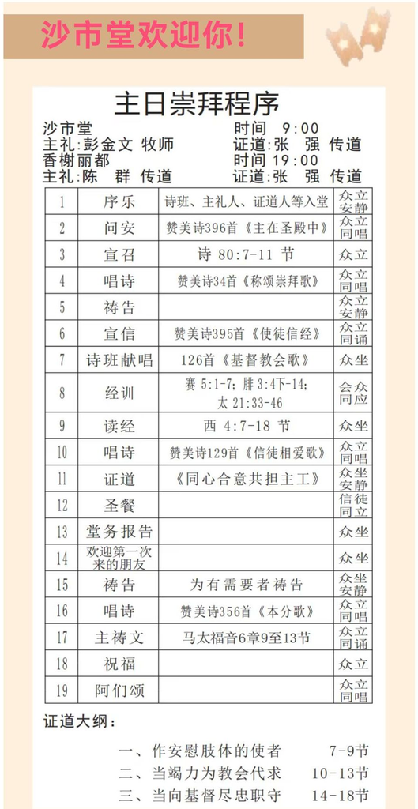

**赞美诗 34《称颂崇拜歌》** ← 第4项 item 4

[figure not shown]

**赞美诗 126《基督教会歌》** ← 第7项 item 7

[figure not shown]

**赞美诗 129《信徒相爱歌》** ← 第10项 item 10

[figure not shown]

**赞美诗 356《本分歌》** ← 第16项 item 16

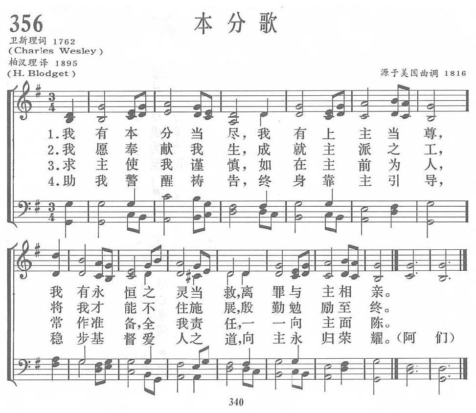

**赞美诗 396《主在圣殿中》** ← 第2项 item 2

[figure not shown]

**赞美诗 395《使徒信经》(1)** ← 第6项 item 6

[figure not shown]

**赞美诗 395《使徒信经》(2)** ← 第6项 item 6

[figure not shown]